# Modelos gaussianos no dirigidos

### Distribución normal multivariada

Recordamos primero la distribución normal bivariada. Sean $(X_1,X_2)$ variables aleatorias continuas. Decimos que estas variables tienen distribución normal bivariada con media $(\mu_1,\mu_2)$ y matriz de varianza y covarianza

$\Sigma=\left( \begin{array}{cc} \sigma_1^2 & \rho\sigma_1\sigma_2\\ \rho\sigma_1\sigma_2 & \sigma_2^2 \end{array} \right)$

La función de densidad de $(X_1,X_2)$ está dada por $f(x_1,x_2)\propto \exp \left\{- \frac{1}{2}(x_1-\mu_1, x_2-\mu_2)\Sigma^{-1} (x_1-\mu_1, x_2-\mu_2)^t \right\}.$

Recordamos las siguientes propiedades:

- La marginal de $X_i$ es normal con media $\mu_i$ y varianza $\sigma_1^2$.
- La condicional de $X_2$ dado $X_1=x_1$ es normal con media dada por la recta de regresión: $\mu_2+\rho\frac{\sigma_2}{\sigma_1}(x_1-\mu_1)$ y varianza $(1-\rho^2)\sigma_2^2$.
- Si $\rho=0$, entonces $X_1$ y $X_2$ son independentes.
- La dependencia de $X_2$ de $X_1$ sólo se da a través de la media condicional (la varianza de la condicional es fija).

Ahora consideramos $(X_1,\ldots, X_k)$ normal multivariada con media $\mu$ y matriz de varianza y covarianza $\Sigma$. $f(x_1,\ldots,x_k)\propto \exp \left\{ -\frac{1}{2}(x-\mu)^t\Sigma^{-1} (x-\mu) \right\}.$ Si escribimos $D=\Sigma^{-1}$ (a $D$ se le llama a veces la **matriz de precisión**, que es simétrica positiva definida), entonces podemos también escribir la densidad conjunta como (agrupando términos y redefiniendo la constante de proporcionalidad):

$f(x_1,\ldots,x_k)\propto \exp \left\{ -\frac{1}{2}\sum_{i,j}D_{ij}x_ix_j -\sum_{i} \gamma_i x_i \right\}.$

Notamos ahora que esta conjunta se expresa naturalmente como un producto de factores donde cada factor depende de dos variables, notamos también que los factores que aparecen dependen de qué coeficientes son iguales a cero de la matriz de precisión $D$. Según la teoría que hemos visto, si el coeficiente de un factor es cero esto implica que las dos variables correspondientes a dicho factor deben ser condicionalmente independientes dada el resto.

\small{ Estandarizamos las variables y examinamos las correlaciones:

```r
library(bnlearn)
library(gRim)
data(marks)
head(marks)
```

```
##   MECH VECT ALG ANL STAT
## 1   77   82  67  67   81
## 2   63   78  80  70   81
## 3   75   73  71  66   81
## 4   55   72  63  70   68
## 5   63   63  65  70   63
## 6   53   61  72  64   73
```

```r
marks_s <- data.frame(scale(marks, center=TRUE, scale=TRUE))
round(var(marks_s), 2)
```

```
##      MECH VECT  ALG  ANL STAT
## MECH 1.00 0.55 0.55 0.41 0.39
## VECT 0.55 1.00 0.61 0.49 0.44
## ALG  0.55 0.61 1.00 0.71 0.66
## ANL  0.41 0.49 0.71 1.00 0.61
## STAT 0.39 0.44 0.66 0.61 1.00
```

Cuya matriz de precisión es

```r
D <- solve(var(marks_s))
round(D, 2)
```

```
##       MECH  VECT   ALG   ANL  STAT
## MECH  1.60 -0.56 -0.51  0.00 -0.04
## VECT -0.56  1.80 -0.66 -0.15 -0.04
## ALG  -0.51 -0.66  3.04 -1.11 -0.86
## ANL   0.00 -0.15 -1.11  2.18 -0.52
## STAT -0.04 -0.04 -0.86 -0.52  1.92
```

Nótese que existen varios coeficientes cercanos a cero.

### Más de la matriz de precisión

Los elementos de la diagonal de $D=\Sigma^{-1}$ pueden interpretarse de la siguiente manera:

- Los elementos de la diagonal están relacionados con la $R^2$ de la regresión de la variable correspondiente con respecto a todas las demás: $D_{ii}= 1/(1-R_i^2)$

```r
fit_alg <- lm(ALG ~ MECH + VECT + ANL + STAT, data = marks_s)
# summary(fit_alg)
R2 <- summary(fit_alg)$r.squared
D_alg <- 1 / (1 - R2)
fit_anl <- lm(ANL ~ MECH + VECT + ALG + STAT, data = marks_s)
R2 <- summary(fit_anl)$r.squared
D_anl <- 1 / (1 - R2)
c(D_alg, D_anl)
```

```
## [1] 3.0 2.2
```

- Los elementos fuera de la diagonal están relacionados con la correlación parcial entre dos variables. La correlación parcial $\rho_{ij|resto}$ entre $X_i$ y $X_j$ es la correlación entre los residuales de la regresión de $X_i$ contra el resto de las variables y los residuales de $X_j$ contra el resto de las variables. Se puede interpretar como la correlación que existe entre $X_i$ y $X_j$ cuando mantenemos el resto de las variables fijas. Cuando este coeficiente es mucho más chico que la correlación usual entre $X_i$ y $X_j$ quiere decir que una buena parte de la correlación de estas variables puede explicarse debido a variación entre el resto de las variables. Específicamente, $\rho_{ij|resto}-\frac{D_{ij}}{\sqrt{D_{ii}D_{jj}}}.$

```r
fit_alg_2 <- lm(ALG ~ MECH + VECT + STAT, data = marks_s)
fit_anl_2 <- lm(ANL ~ MECH + VECT + STAT, data = marks_s)
cor(residuals(fit_alg_2), residuals(fit_anl_2))
```

```
## [1] 0.43
```

```r
- D[3, 4] / sqrt(D[3, 3] * D[4, 4])
```

```
## [1] 0.43
```

```r
cor(marks_s)[3, 4]
```

```
## [1] 0.71
```

Podemos examinar todas las correlaciones parciales haciendo:

```r
D <- solve(cor(marks_s))
parciales_D <- -(t(D * (1/sqrt(diag(D)))) * (1 / sqrt(diag(D))))
round(parciales_D, 2)
```

```
##       MECH  VECT   ALG   ANL  STAT
## MECH -1.00  0.33  0.23  0.00  0.02
## VECT  0.33 -1.00  0.28  0.08  0.02
## ALG   0.23  0.28 -1.00  0.43  0.36
## ANL   0.00  0.08  0.43 -1.00  0.25
## STAT  0.02  0.02  0.36  0.25 -1.00
```

En cada una de las imágenes de abajo indica si la estructura de la gráfica del lado derecho corresponde a la matriz de correlación parcial (cuadro indica valor distinto a cero y vacío indica cero).

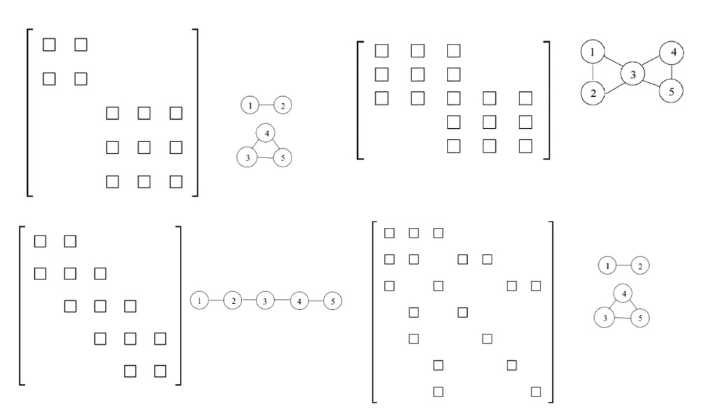

### Independencia condicional para la normal multivariada

De la discusión anterior, vemos que cuando $(X_1,\ldots, X_k)$ es normal multivariada, entonces $X_i$ es independiente de $X_j$ dado el resto de las variables si y sólo si la correlación parcial es cero, o de otra forma, cuando $D_{ij}=0$.

Podemos ahora apelar a nuestros resultados anteriores (propiedades de Markov por pares, global y distribución de Gibbs) para demostrar el siguiente teorema (aunque también se puede resolver mediante cálculo):

Si $X=(X_a,X_b, X_c)$ es normal multivariada, donde $X_a,X_b,X_c$ son bloques de variables. Los vectores $X_a$ y $X_b$ son condicionalmente independientes dado $X_c$ si y sólo si el bloque $D_{ab}$ de la precisión o varianza inversa $D=\Sigma^{-1}$ es igual a cero.

```r
round(cov(marks))
```

```
##      MECH VECT ALG ANL STAT
## MECH  306  127 102 106  117
## VECT  127  173  85  95   99
## ALG   102   85 113 112  122
## ANL   106   95 112 220  156
## STAT  117   99 122 156  298
```

Si estandarizamos las variables para que la variabilidad sea comparable, obtenemos la matriz

```r
cor(marks)
```

```
##      MECH VECT  ALG  ANL STAT
## MECH 1.00 0.55 0.55 0.41 0.39
## VECT 0.55 1.00 0.61 0.49 0.44
## ALG  0.55 0.61 1.00 0.71 0.66
## ANL  0.41 0.49 0.71 1.00 0.61
## STAT 0.39 0.44 0.66 0.61 1.00
```

Cuya inversa es

```r
inv_1 <- round(solve(cor(marks)), 2)
inv_1
```

```
##       MECH  VECT   ALG   ANL  STAT
## MECH  1.60 -0.56 -0.51  0.00 -0.04
## VECT -0.56  1.80 -0.66 -0.15 -0.04
## ALG  -0.51 -0.66  3.04 -1.11 -0.86
## ANL   0.00 -0.15 -1.11  2.18 -0.52
## STAT -0.04 -0.04 -0.86 -0.52  1.92
```

Donde vemos los coeficientes de esta inversa para los pares ANL-MECH, ANL-VECT, VEC-STAT, MECH-STAT son cercanos a cero. Esto implica que son variables cercanas a la independencia dado el resto de las variables. Así que un modelo apropiado para estos datos tiene todas las aristas, excepto la lista que mencionó arriba. Terminamos entonces con la gráfica

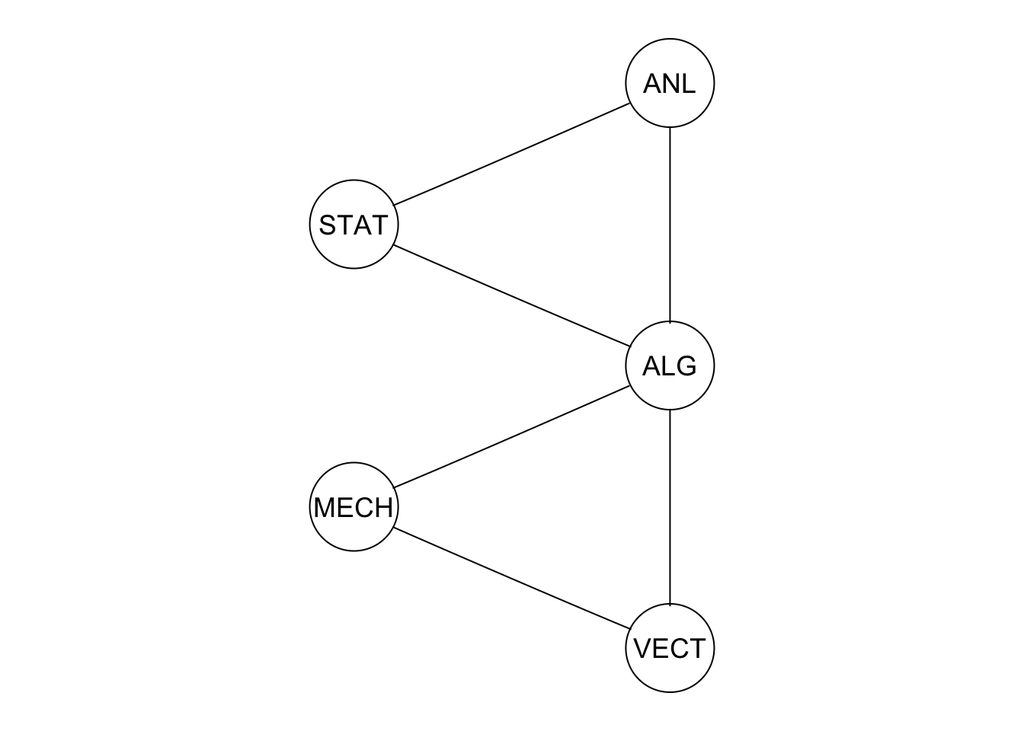

```r
library(Rgraphviz)
data(marks)
ug_1 <- ug(~ ANL:STAT + ALG:STAT + ALG:ANL + MECH:ALG + VECT:ALG + VECT:MECH)
plot(ug_1)
```

Podemos graficar mostrando las correlaciones parciales:

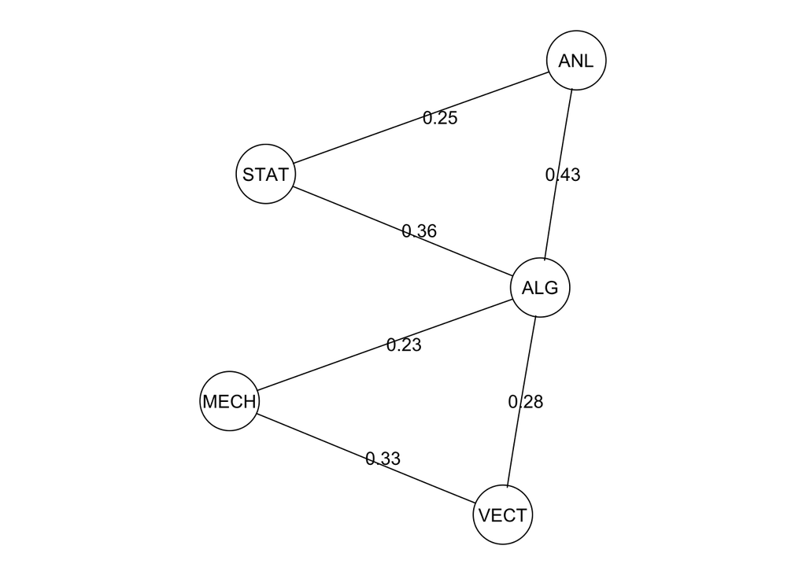

```r
nombres <- sapply(edgeList(ug_1), function(x){
  nombre <-  paste0('', paste(c(x[1], x[2]), collapse = "~"), '')
  nombre
})
peso <- sapply(edgeList(ug_1), function(x){
  peso <- as.character(round(parciales_D[x[1], x[2]], 2))
})
etiquetas <- peso
names(etiquetas) <- nombres
Rgraphviz::plot(ug_1, edgeAttrs = list(label = etiquetas))
```

### Estimación de máxima verosimilitud con estructura conocida

De esta forma, vemos que cuando tenemos una estructura no dirigida dada, nuestro trabajo es estimar la matriz de covarianza (o la precisión) con restricciones de ceros dadas por las independencias condicionales.

Podemos entonces maximizar la verosimilitud con las restricciones sobre la inversa de la matriz de varianza y covarianza. En general no es problema trivial.

### Aprendizaje de estructura

Igual que en modelos log-lineales para datos categóricos, podemos ajustar modelos hacia atrás y hacia adelante (agregando/eliminando aristas) usando el BIC/AIC como criterio de selección, con distintas restricciones sobre la matriz de precisión.

**Ejemplo** En este ejemplo consideramos las estaturas de los dos padres y de dos de sus hijas seleccionados al azar (entre las familias que tienen al menos dos hijas).

```r
library(plyr)
```

```r
library(gRim)
library(HistData)
data(GaltonFamilies)
dat <- GaltonFamilies
dat.2 <- ddply(dat, c('family'), function(df){
  df$id_child <- sample(1:nrow(df), nrow(df))
  df
})
dat.female <- subset(dat.2,  gender=='female')
dat.female <- ddply(dat.female, c('family'), transform,

  num.female=length(childHeight))

dat.female.2 <- subset(dat.female, num.female>1)
set.seed(28)
dat.3 <- ddply(dat.female.2, c('family'), function(df){
  df$id_child <- sample(1:nrow(df), nrow(df))
  subset(df, id_child<3)
})
library(reshape2)
dat.4 <- dcast(dat.3, family+father+mother~ id_child, value.var='childHeight')
names(dat.4)[c(4,5)] <- c('h1','h2')
sigma <- var(dat.4[, c('father','mother', 'h1','h2')])
sigma
```

```
##        father mother  h1  h2
## father   7.17  -0.19 2.3 2.0
## mother  -0.19   4.66 1.2 1.1
## h1       2.29   1.23 5.5 1.5
## h2       2.04   1.11 1.5 4.9
```

```r
solve((sigma))
```

```
##        father mother     h1     h2
## father  0.180  0.040 -0.066 -0.064
## mother  0.040  0.244 -0.056 -0.055
## h1     -0.066 -0.056  0.229 -0.029
## h2     -0.064 -0.055 -0.029  0.251
```

```
## . FORWARD: type=unrestricted search=all, criterion=aic(2.00), alpha=0.00
## . Initial model: is graphical=TRUE is decomposable=TRUE
##   change.AIC  -14.4621 Edge added: father h1
##   change.AIC  -12.5977 Edge added: father h2
##   change.AIC   -4.9947 Edge added: h1 mother
##   change.AIC   -7.9502 Edge added: h2 mother
##   change.AIC   -8.2410 Edge added: father mother
```

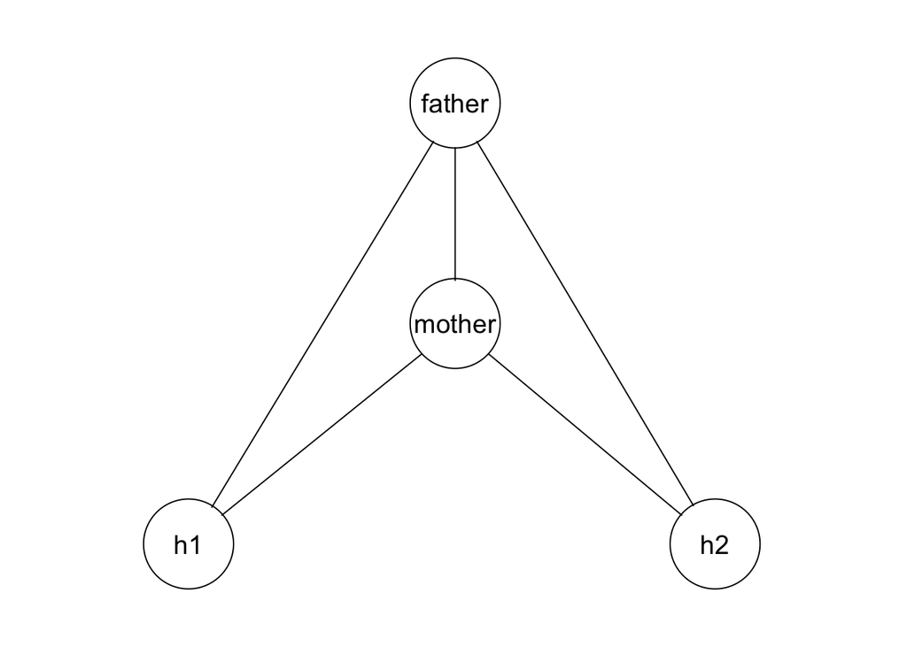

```r
mod.1 <- cmod(~.^1, data=dat.4[,c('father','mother', 'h1','h2')])
plot(mod_hijas <- forward(mod.1, type='unrestricted'))
```

Podemos examinar la matriz de precisión ajustada:

```r
D <- mod_hijas$fitinfo$K
D
```

```
##        father mother     h1     h2
## father  0.186  0.044 -0.074 -0.073
## mother  0.044  0.250 -0.063 -0.062
## h1     -0.074 -0.063  0.228  0.000
## h2     -0.073 -0.062  0.000  0.250
```

y para checar el ajuste comparamos la matriz de covarianzas empírica con la ajustada:

```r
round(cor(dat.4[, -1]), 2)
```

```
##        father mother   h1   h2
## father   1.00  -0.03 0.36 0.34
## mother  -0.03   1.00 0.24 0.23
## h1       0.36   0.24 1.00 0.28
## h2       0.34   0.23 0.28 1.00
```

```r
round(cov2cor(solve(D)), 2)
```

```
##        father mother   h1   h2
## father   1.00  -0.03 0.36 0.34
## mother  -0.03   1.00 0.24 0.23
## h1       0.36   0.24 1.00 0.19
## h2       0.34   0.23 0.19 1.00
```

Podemos comparar con

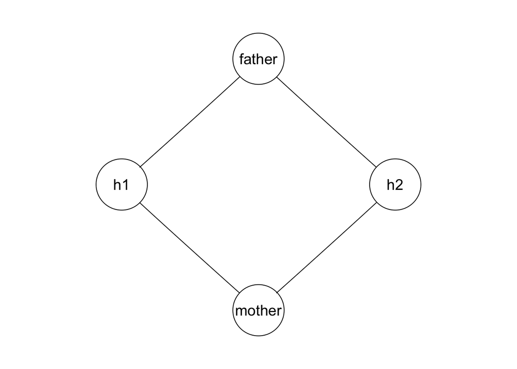

```r
mod.hijas.2 <- update(mod_hijas, list(dedge = ~mother:father))
plot(mod.hijas.2)
```

```r
mod.hijas.2
```

```
## Model: A cModel with 4 variables
##  graphical :  TRUE  decomposable : FALSE
##  -2logL    :        2059.38 mdim :    8 aic :      2075.38
##  ideviance :          43.03 idf  :    4 bic :      2097.41
##  deviance  :           6.77 df   :    2
```

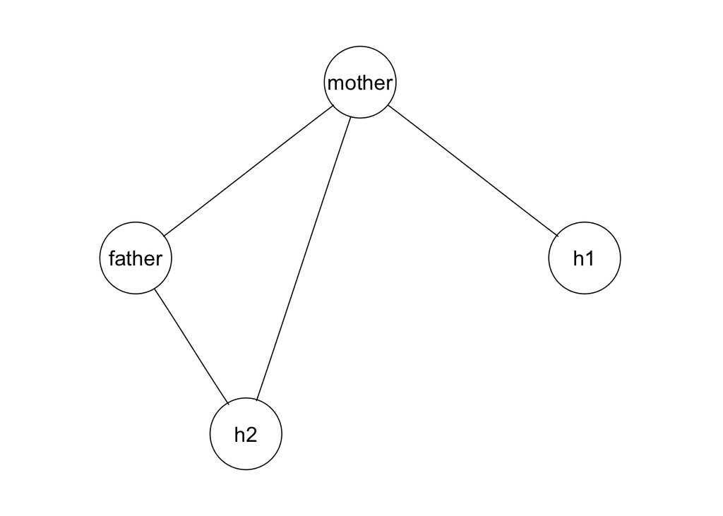

```r
mod.hijas.3 <- update(mod_hijas, list(dedge=~father:h1))
plot(mod.hijas.3)
```

```r
mod.hijas.3
```

```
## Model: A cModel with 4 variables
##  graphical :  TRUE  decomposable :  TRUE
##  -2logL    :        2072.68 mdim :    8 aic :      2088.68
##  ideviance :          29.73 idf  :    4 bic :      2110.71
##  deviance  :          20.07 df   :    2
```

Nótese que la estimación de la matriz de varianza y covarianza está cercana a la empírica:

```r
D <- mod.hijas.2$fitinfo$K
round(cor(dat.4[,-1]),2)
```

```
##        father mother   h1   h2
## father   1.00  -0.03 0.36 0.34
## mother  -0.03   1.00 0.24 0.23
## h1       0.36   0.24 1.00 0.28
## h2       0.34   0.23 0.28 1.00
```

```r
round(cov2cor(solve(D)),2)
```

```
##        father mother   h1   h2
## father   1.00   0.14 0.36 0.34
## mother   0.14   1.00 0.24 0.23
## h1       0.36   0.24 1.00 0.16
## h2       0.34   0.23 0.16 1.00
```

Mientras que eliminar father-h1 muestra un desajuste más considerable:

```r
D <- mod.hijas.3$fitinfo$K
round(cor(dat.4[,-1]),2)
```

```
##        father mother   h1   h2
## father   1.00  -0.03 0.36 0.34
## mother  -0.03   1.00 0.24 0.23
## h1       0.36   0.24 1.00 0.28
## h2       0.34   0.23 0.28 1.00
```

```r
round(cov2cor(solve(D)),2)
```

```
##        father mother    h1   h2
## father   1.00  -0.03 -0.01 0.34
## mother  -0.03   1.00  0.24 0.23
## h1      -0.01   0.24  1.00 0.06
## h2       0.34   0.23  0.06 1.00
```

**Ejemplo: datos bodyfat**

```r
bodyfat <- read.table('bodyfat.txt', header=T)
head(bodyfat)
```

```
##   densidad grasacorp edad peso estatura cuello pecho abdomen cadera muslo
## 1      1.1      12.3   23  154       68     36    93      85     94    59
## 2      1.1       6.1   22  173       72     38    94      83     99    59
## 3      1.0      25.3   22  154       66     34    96      88     99    60
## 4      1.1      10.4   26  185       72     37   102      86    101    60
## 5      1.0      28.7   24  184       71     34    97     100    102    63
## 6      1.1      20.9   24  210       75     39   104      94    108    66
##   rodilla tobillo biceps antebrazo muñeca
## 1      37      22     32        27     17
## 2      37      23     30        29     18
## 3      39      24     29        25     17
## 4      37      23     32        29     18
## 5      42      24     32        28     18
## 6      42      26     36        31     19
```

```r
cov(bodyfat)
```

```
##           densidad grasacorp    edad   peso estatura cuello  pecho abdomen
## densidad   0.00036     -0.16  -0.067  -0.33   0.0068 -0.022  -0.11   -0.16
## grasacorp -0.15732     70.04  30.738 150.62  -2.7433  9.980  49.57   73.40
## edad      -0.06659     30.74 158.811  -4.72  -7.9230  3.477  18.75   31.31
## peso      -0.33227    150.62  -4.721 863.72  33.1856 59.348 221.55  281.41
## estatura   0.00682     -2.74  -7.923  33.19  13.4165  2.259   4.17    3.47
## cuello    -0.02188      9.98   3.477  59.35   2.2591  5.909  16.08   19.77
## pecho     -0.10952     49.57  18.746 221.55   4.1654 16.084  71.07   83.25
## abdomen   -0.16396     73.40  31.310 281.41   3.4683 19.766  83.25  116.27
## cadera    -0.08308     37.48  -4.544 198.10   4.4713 12.799  50.09   67.52
## muslo     -0.05526     24.59 -13.238 134.03   2.8544  8.879  32.30   43.40
## rodilla   -0.02272     10.27   0.532  60.47   2.5270  3.942  14.63   19.17
## tobillo   -0.00854      3.77  -2.244  30.57   1.6436  1.969   6.90    8.28
## biceps    -0.02801     12.47  -1.567  71.07   2.2998  5.370  18.54   22.32
## antebrazo -0.01352      6.11  -2.166  37.43   1.6923  3.063   9.88   10.97
## muñeca    -0.00579      2.71   2.512  20.02   1.1013  1.690   5.20    6.24
##            cadera   muslo rodilla tobillo biceps antebrazo  muñeca
## densidad   -0.083  -0.055  -0.023 -0.0085 -0.028    -0.014 -0.0058
## grasacorp  37.483  24.587  10.267  3.7725 12.472     6.111  2.7078
## edad       -4.544 -13.238   0.532 -2.2439 -1.567    -2.166  2.5122
## peso      198.099 134.032  60.473 30.5686 71.071    37.431 20.0230
## estatura    4.471   2.854   2.527  1.6436  2.300     1.692  1.1013
## cuello     12.799   8.879   3.942  1.9690  5.370     3.063  1.6904
## pecho      50.094  32.303  14.629  6.9013 18.540     9.883  5.1959
## abdomen    67.522  43.399  19.172  8.2832 22.316    10.967  6.2398
## cadera     51.324  33.715  14.228  6.7801 16.001     7.890  4.2142
## muslo      33.715  27.562  10.119  4.8032 12.078     6.013  2.7383
## rodilla    14.228  10.119   5.817  2.5001  4.946     2.709  1.4962
## tobillo     6.780   4.803   2.500  2.8727  2.483     1.435  0.8959
## biceps     16.001  12.078   4.946  2.4828  9.128     4.141  1.7830
## antebrazo   7.890   6.013   2.709  1.4352  4.141     4.083  1.1047
## muñeca      4.214   2.738   1.496  0.8959  1.783     1.105  0.8716
```

```r
precision <- round(100*solve(cor(bodyfat[,-1])))
round(100*cov2pcor(cov(bodyfat)))
```

```
##           densidad grasacorp edad peso estatura cuello pecho abdomen
## densidad       100       -96    5    8        0      1     7     -14
## grasacorp      -96       100    8    4       -2     -3     6       4
## edad             5         8  100  -19      -13     10     3      30
## peso             8         4  -19  100       44     27    40      23
## estatura         0        -2  -13   44      100     -3   -21      -6
## cuello           1        -3   10   27       -3    100     3      10
## pecho            7         6    3   40      -21      3   100      39
## abdomen        -14         4   30   23       -6     10    39     100
## cadera           6         3   -7   52      -25    -18   -19      26
## muslo           -6        -3  -37    7      -20     12   -15       4
## rodilla         -1         0   25   25        9    -15    -9      -6
## tobillo        -10        -8  -10   19       -6     -9    -2     -12
## biceps          -9        -7    7   19       -5      9     9     -15
## antebrazo       -1         4  -18    3       -1     13    12     -13
## muñeca           6         0   35   11        9     26    -2       0
##           cadera muslo rodilla tobillo biceps antebrazo muñeca
## densidad       6    -6      -1     -10     -9        -1      6
## grasacorp      3    -3       0      -8     -7         4      0
## edad          -7   -37      25     -10      7       -18     35
## peso          52     7      25      19     19         3     11
## estatura     -25   -20       9      -6     -5        -1      9
## cuello       -18    12     -15      -9      9        13     26
## pecho        -19   -15      -9      -2      9        12     -2
## abdomen       26     4      -6     -12    -15       -13      0
## cadera       100    33       4      -4     -7        -8      0
## muslo         33   100      27      -2     25        -1     -4
## rodilla        4    27     100      17     -8         9      7
## tobillo       -4    -2      17     100     -5        -3     25
## biceps        -7    25      -8      -5    100        28      6
## antebrazo     -8    -1       9      -3     28       100     20
## muñeca         0    -4       7      25      6        20    100
```

```r
bodyfat.1 <- bodyfat[,c('grasacorp','abdomen','peso','estatura','biceps','antebrazo',
  'rodilla','muñeca')]
summary(bodyfat.1)
```

```
##    grasacorp     abdomen         peso        estatura      biceps
##  Min.   : 0   Min.   : 69   Min.   :118   Min.   :30   Min.   :25
##  1st Qu.:12   1st Qu.: 85   1st Qu.:159   1st Qu.:68   1st Qu.:30
##  Median :19   Median : 91   Median :176   Median :70   Median :32
##  Mean   :19   Mean   : 93   Mean   :179   Mean   :70   Mean   :32
##  3rd Qu.:25   3rd Qu.: 99   3rd Qu.:197   3rd Qu.:72   3rd Qu.:34
##  Max.   :48   Max.   :148   Max.   :363   Max.   :78   Max.   :45
##    antebrazo     rodilla       muñeca
##  Min.   :21   Min.   :33   Min.   :15.8
##  1st Qu.:27   1st Qu.:37   1st Qu.:17.6
##  Median :29   Median :38   Median :18.3
##  Mean   :29   Mean   :39   Mean   :18.2
##  3rd Qu.:30   3rd Qu.:40   3rd Qu.:18.8
##  Max.   :35   Max.   :49   Max.   :21.4
```

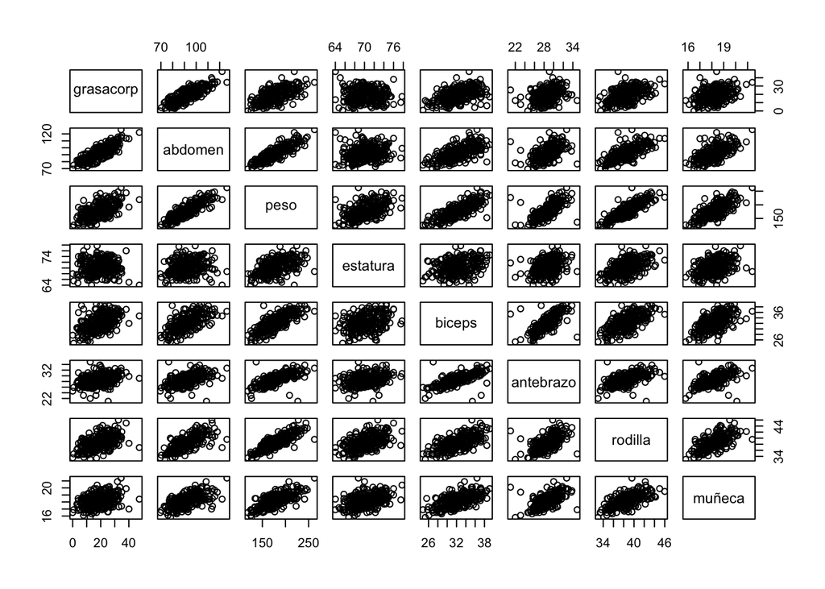

```r
bodyfat.1 <- subset(bodyfat.1, estatura > 30 & peso <300)
pairs(bodyfat.1)
```

Usamos el criterio bic ajustando modelos hacia adelante obtenemos:

```
## . FORWARD: type=unrestricted search=all, criterion=aic(5.52), alpha=0.00
## . Initial model: is graphical=TRUE is decomposable=TRUE
##   change.AIC -354.8385 Edge added: abdomen peso
##   change.AIC -304.1353 Edge added: peso rodilla
##   change.AIC -278.1341 Edge added: abdomen grasacorp
##   change.AIC -234.1223 Edge added: peso biceps
##   change.AIC -180.9975 Edge added: peso muñeca
##   change.AIC -163.5689 Edge added: biceps antebrazo
##   change.AIC  -70.7975 Edge added: peso estatura
##   change.AIC -211.9549 Edge added: estatura grasacorp
##   change.AIC  -83.0803 Edge added: abdomen estatura
##   change.AIC  -46.2559 Edge added: muñeca antebrazo
##   change.AIC  -26.0306 Edge added: muñeca grasacorp
##   change.AIC  -11.4932 Edge added: peso antebrazo
##   change.AIC   -9.9454 Edge added: estatura rodilla
##   change.AIC   -8.7992 Edge added: biceps estatura
##   change.AIC  -26.5494 Edge added: biceps abdomen
##   change.AIC   -4.1848 Edge added: peso grasacorp
##   change.AIC   -4.3748 Edge added: abdomen antebrazo
##   change.AIC   -2.7400 Edge added: estatura antebrazo
##   change.AIC   -0.4849 Edge added: abdomen muñeca
##   change.AIC   -1.0522 Edge added: rodilla muñeca
```

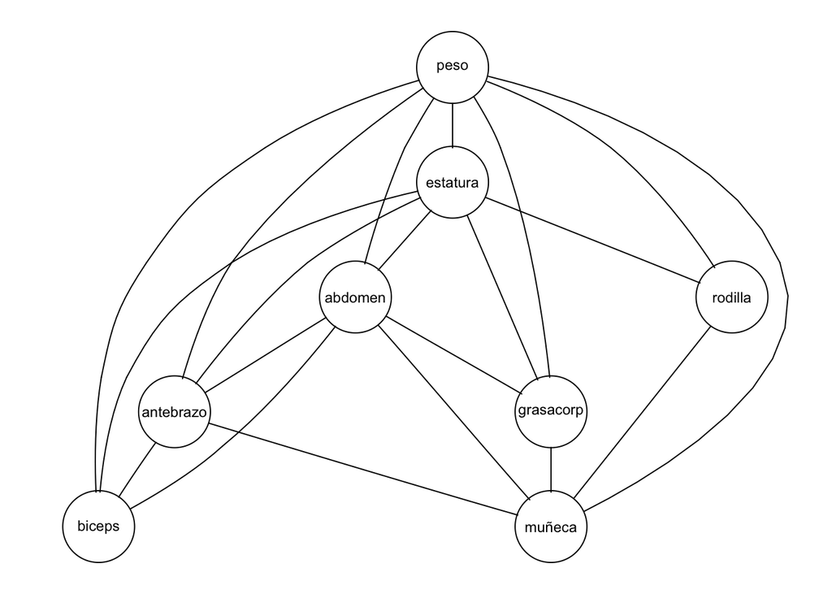

```r
mod.1 <- cmod(~.^1, data=bodyfat.1)
plot(mod.2 <- forward(mod.1, k=log(nrow(bodyfat.1)), type='unrestricted'))
```

Podemos checar el ajuste del modelo verificando que la matriz ajustada de correlaciones es similar a la observada:

```r
D <- mod.2$fitinfo$K
round(cor(bodyfat.1[,]),2)
```

```
##           grasacorp abdomen peso estatura biceps antebrazo rodilla muñeca
## grasacorp      1.00    0.82 0.62    -0.03   0.48      0.36    0.49   0.34
## abdomen        0.82    1.00 0.87     0.19   0.66      0.53    0.71   0.60
## peso           0.62    0.87 1.00     0.51   0.79      0.68    0.84   0.73
## estatura      -0.03    0.19 0.51     1.00   0.32      0.32    0.51   0.40
## biceps         0.48    0.66 0.79     0.32   1.00      0.70    0.65   0.61
## antebrazo      0.36    0.53 0.68     0.32   0.70      1.00    0.58   0.60
## rodilla        0.49    0.71 0.84     0.51   0.65      0.58    1.00   0.66
## muñeca         0.34    0.60 0.73     0.40   0.61      0.60    0.66   1.00
```

```r
round(cov2cor(solve(D)),2)
```

```
##           grasacorp abdomen peso estatura biceps antebrazo rodilla muñeca
## grasacorp      1.00    0.82 0.62    -0.03   0.45      0.33    0.47   0.34
## abdomen        0.82    1.00 0.87     0.19   0.66      0.53    0.71   0.60
## peso           0.62    0.87 1.00     0.51   0.79      0.68    0.84   0.73
## estatura      -0.03    0.19 0.51     1.00   0.32      0.32    0.51   0.40
## biceps         0.45    0.66 0.79     0.32   1.00      0.70    0.66   0.60
## antebrazo      0.33    0.53 0.68     0.32   0.70      1.00    0.58   0.60
## rodilla        0.47    0.71 0.84     0.51   0.66      0.58    1.00   0.66
## muñeca         0.34    0.60 0.73     0.40   0.60      0.60    0.66   1.00
```

Y vemos que en en efecto estas dos matrices son muy similares.

En muchos casos, estos modelos presentan algunas correlaciones débiles que, aunque nos pueden interesar, pueden hacer difícil entender los rasgos importantes de nuestros datos. Vale la pena examinar ajustes penalizando por complejidad más fuertemente, y viendo qué tanto cambia la calidad del ajuste. Por ejemplo, si incrementamos la penalización (el bic da una penalización de 5):

```
## . FORWARD: type=unrestricted search=all, criterion=aic(20.00), alpha=0.00
## . Initial model: is graphical=TRUE is decomposable=TRUE
##   change.AIC -340.3599 Edge added: abdomen peso
##   change.AIC -289.6568 Edge added: peso rodilla
##   change.AIC -263.6555 Edge added: abdomen grasacorp
##   change.AIC -219.6437 Edge added: peso biceps
##   change.AIC -166.5189 Edge added: peso muñeca
##   change.AIC -149.0904 Edge added: biceps antebrazo
##   change.AIC  -56.3189 Edge added: peso estatura
##   change.AIC -197.4764 Edge added: estatura grasacorp
##   change.AIC  -68.6018 Edge added: abdomen estatura
##   change.AIC  -31.7774 Edge added: muñeca antebrazo
##   change.AIC  -11.5520 Edge added: muñeca grasacorp
```

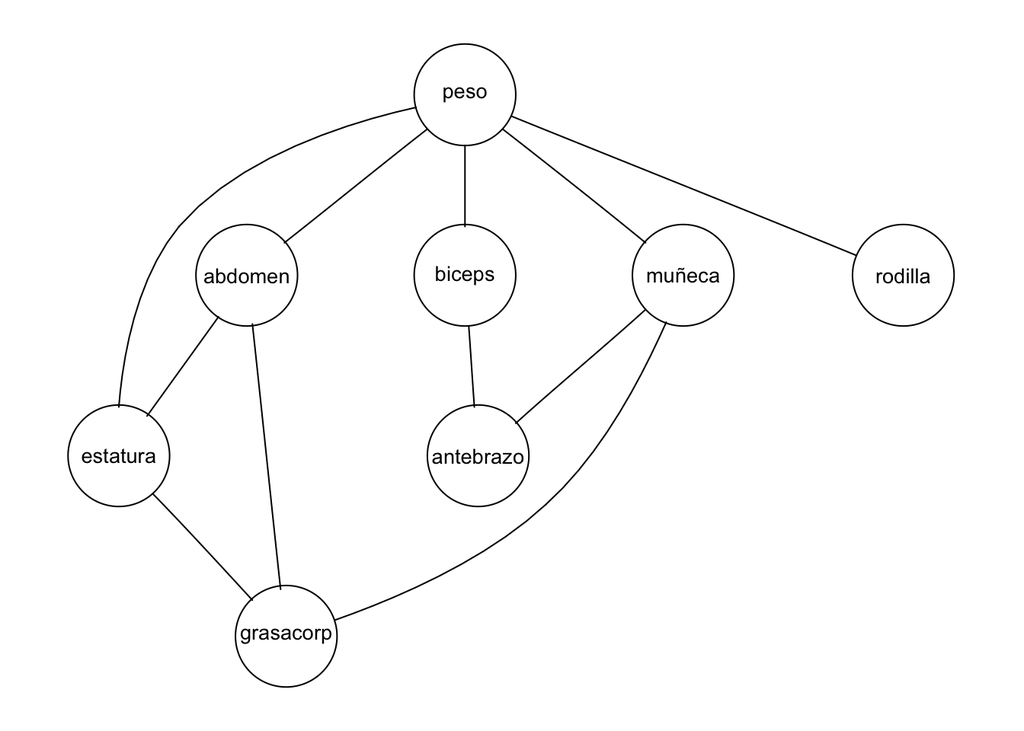

```r
plot(mod.3 <- forward(mod.1, k=20, type='unrestricted'))
```

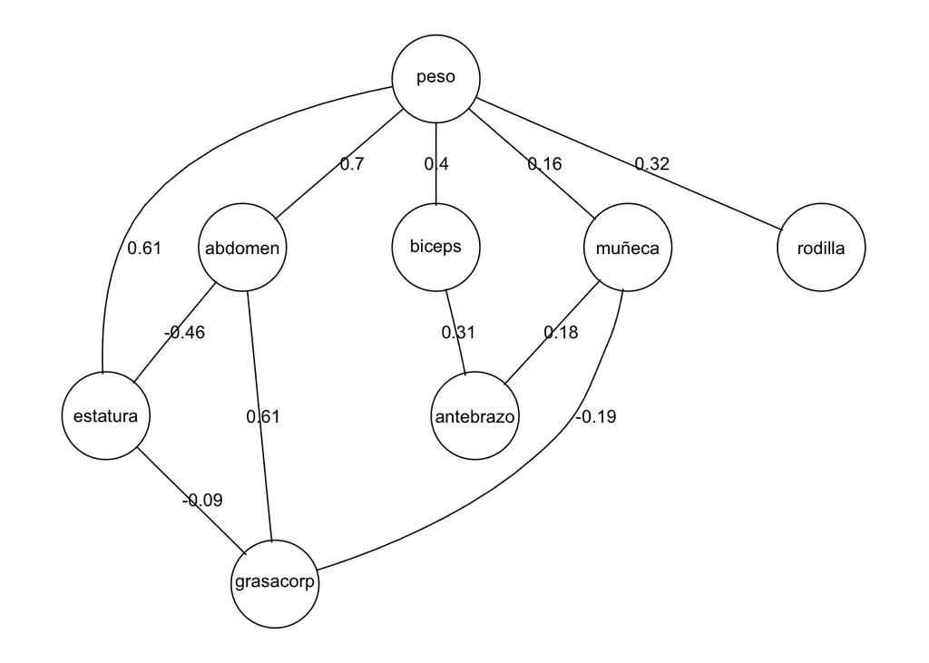

```r
D <- mod.2$fitinfo$K

parciales.D <- -(t(D*(1/sqrt(diag(D))))*(1/sqrt(diag(D))))
graf.1 <- ugList(mod.3$glist)
nombres <- sapply(edgeList(graf.1), function(x){
  nombre <-  paste0('',paste(c(x[1],x[2]), collapse="~"),'')
  nombre
})
peso <- sapply(edgeList(graf.1), function(x){
  peso <- as.character(round(parciales.D[x[1],x[2]],2))
})
etiquetas <- peso
names(etiquetas) <- nombres
plot(graf.1, edgeAttrs=list(label=etiquetas))
```

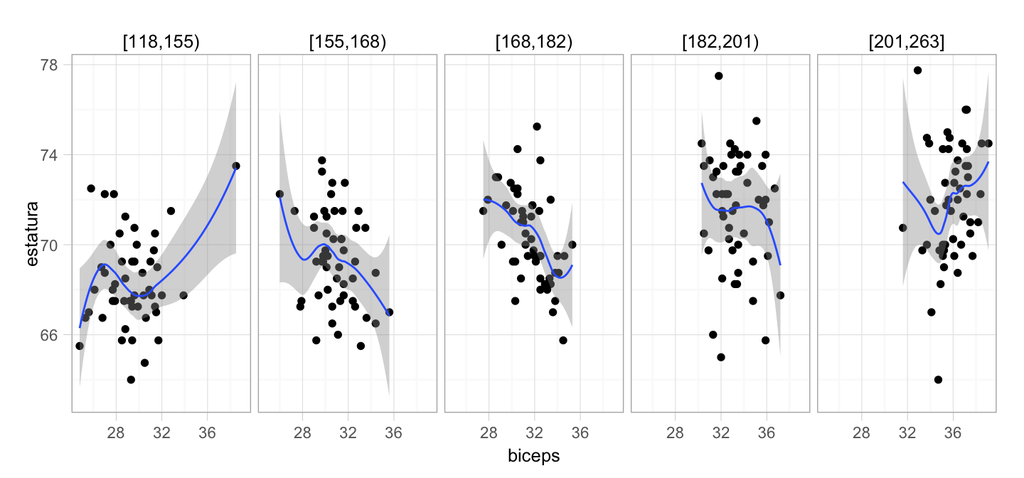

```r
library(Hmisc)
library(ggplot2)
bodyfat.2 <- bodyfat.1
bodyfat.2$grupo.peso <- cut2(bodyfat.2$peso, g=5)
ggplot(bodyfat.2, aes(x=biceps, y=estatura)) +
  geom_point() +
  facet_wrap(~grupo.peso, nrow = 1) +
  geom_smooth()
```

Sin condicionar observamos,

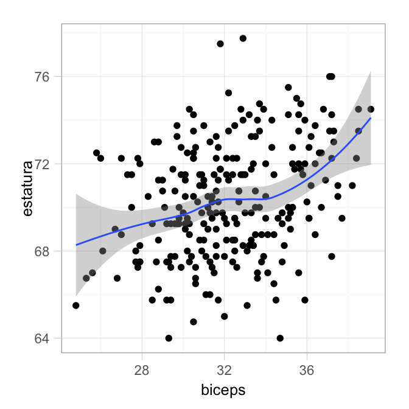

```r
ggplot(bodyfat.2, aes(x=biceps, y=estatura)) +
  geom_point() + geom_smooth()
```

Comparando las matrices de correlaciones.

```r
D <- mod.3$fitinfo$K
round(cor(bodyfat.1[,]),2)
```

```
##           grasacorp abdomen peso estatura biceps antebrazo rodilla muñeca
## grasacorp      1.00    0.82 0.62    -0.03   0.48      0.36    0.49   0.34
## abdomen        0.82    1.00 0.87     0.19   0.66      0.53    0.71   0.60
## peso           0.62    0.87 1.00     0.51   0.79      0.68    0.84   0.73
## estatura      -0.03    0.19 0.51     1.00   0.32      0.32    0.51   0.40
## biceps         0.48    0.66 0.79     0.32   1.00      0.70    0.65   0.61
## antebrazo      0.36    0.53 0.68     0.32   0.70      1.00    0.58   0.60
## rodilla        0.49    0.71 0.84     0.51   0.65      0.58    1.00   0.66
## muñeca         0.34    0.60 0.73     0.40   0.61      0.60    0.66   1.00
```

```r
round(cov2cor(solve(D)),2)
```

```
##           grasacorp abdomen peso estatura biceps antebrazo rodilla muñeca
## grasacorp      1.00    0.82 0.64    -0.03   0.49      0.35    0.54   0.34
## abdomen        0.82    1.00 0.87     0.19   0.68      0.52    0.74   0.58
## peso           0.64    0.87 1.00     0.51   0.79      0.61    0.84   0.73
## estatura      -0.03    0.19 0.51     1.00   0.41      0.34    0.43   0.45
## biceps         0.49    0.68 0.79     0.41   1.00      0.70    0.66   0.62
## antebrazo      0.35    0.52 0.61     0.34   0.70      1.00    0.52   0.60
## rodilla        0.54    0.74 0.84     0.43   0.66      0.52    1.00   0.61
## muñeca         0.34    0.58 0.73     0.45   0.62      0.60    0.61   1.00
```

Donde vemos que este modelo más simple recupera razonablemente bien la estructura de covarianza.

Utiliza los datos *carcass* para crear un modelo gráfico Gaussiano. ¿Qué relaciones de independencia condicional lees en la gráfica?

### Supuesto de normalidad multivariada

El supuesto de normalidad multivariada es en general difícil de verificar. Generalmente, se considera que la pregunta interesante es si los datos son suficientemente cercanos a normalidad para aplicar un procedimiento dado. Existen diagnósticos, pero aquí consideramos que estos modelos gaussianos, típicamente, pueden utilizarse más como procedimientos exploratorios.